# Chapter 3 Line Search Methods: Algorithm 3.5

1. Opitimization : $$x_{k+1} = x_k + \alpha p_k \tag{3.1}$$
2. line search: 寻找最优的$\alpha$.
3. objecttive function: $$f(x) = $$f(x_k + \alpha p_k)$$
4. 泰勒展开式：$f(x_k + \alpha p_k) = f_k + \nabla f_k^T p_k \alpha$
5. 其中 $\nabla f_k^T p_k$是方向导数，只是一个数而已。方向导数本质就是导数。
6. 令$$\phi(\alpha) = \phi(0) + \phi'(0) \alpha $$

其中 $\phi(0) = f_k,\phi'(0) =\nabla f_k^T p_k$  
7. Line Search:机器学习中的learning rate。

- Exact Line Search:$\phi'(\alpha) = 0$.(理科)
- Inexact Line Search:只需要充分下降。（工科技术）
- 见上节课$\phi(\alpha)$的表达式。近似看成不可解析；其次，无必要。单次迭代无需最优。
- Inexact line search:只需要保证每次函数值下降。
8. Wolfe condition:

$$\begin{aligned} f(x_k + \alpha p_k) &\le f_k + c_l \alpha \nabla f_k^T p_k \\ \nabla f(x_k + \alpha p_k)^T p_k &\ge c_u \nabla f_k^T p_k \end{aligned} \tag{3.6}$$

等价写法： $$\begin{aligned} \phi'(\alpha) &\le \phi(0) + c_l \phi'(0) \alpha \\ \phi'(\alpha) &\ge c_2 \phi'(0) \alpha \end{aligned} \tag{3.6-2}$$ 9. 解析Wolfe condition:

```julia
using DelimitedFiles # 分隔符 文件
using Plots
using LinearAlgebra

data = readdlm("ex2data2.txt", ',', Float64, '\n') # dlm: 分隔符
# dlm: Delimited;
A = data[:, 1:2]
y = data[:, 3]

function plotData(A, y)
    scatter(A[y .== 0, 1], A[y .== 0, 2], marker=:+, markersize=7)
    scatter!(A[y.== 1, 1], A[y .== 1, 2], marker=:o, markersize=7)
end
```

```
plotData (generic function with 1 method)
```

```julia
sigmoid(z) = 1 / (1 + exp(-z))
function f(θ, X=X, y=y)
    # 交叉熵
    z = X * θ
    h = @. sigmoid(z)
    m = length(y)
    J = - (y' * log.(h) + (1.0 .- y)' * log.(1.0 .- h)) / m
    J
end
# f: cost
function ∇f(θ, X=X, y=y)
    z = X * θ
    h = @. sigmoid(z)
    m = length(y)
    grad = X' * (h - y) / m
    grad
end
function mapFeature(u, v)
    degree = 6 # 1, u ,v ,u^2 , u^3, u^2v, uv^2, v^3, ..., u^6, u^5v, u^4v^2,...,v^6
    out = ones(length(v)) # [[1, 1, 1, ..., 1]]
    for i = 1:degree
        for j = 0:i
            out = hcat(out, u.^(i-j) .* v .^j)
        end
    end
    out
end

function make_ϕdϕ(x,p) # 上节课：x_k ，p_k
    function ϕ(α)
        f(x + α * p)
    end
    function dϕ(α)
        ∇f(x+α*p)'*p
    end
    ϕ,dϕ
end
X = mapFeature(A[:,1],A[:,2])
θ = randn(28);p = -∇f(θ)
ϕ,dϕ = make_ϕdϕ(θ,p)
f(θ),ϕ(0),∇f(θ)'*p,dϕ(0)
```

```
(0.9123993047314538, 0.9123993047314538, -0.05242282913659223, -0.05242282913659223)
```

## Interpolate 插值法

$\phi(\alpha)$ 只是一个一元函数，表达式很复杂，实际接近一抛物线，选取三个点，求取抛物线近似拟合原函数。 $$\phi_q(\alpha) = \bigg(\frac {\phi(\alpha_0)-\phi(0)-\alpha_0\phi'(0)}{\alpha_0^2}\bigg) \alpha^2 + \phi'(0)\alpha + \phi(0). \tag{3.57}$$

- 简单的官方定义： 例：3.57只是一个抛物线函数，其中$\phi(\alpha_0),\phi(0),\phi'(0)$是常数。

$$f(x) = ax^2 + bx + c;x=-\frac b {2a} \tag{3.58}$$

如果$\alpha _1$由(3.58)得到不满足条件，再用一元三次函数进行拟合。 $$\phi_c(\alpha) = a\alpha^3 + b\alpha^2 + \alpha \phi'(0)+ \alpha(0)$$ 其中系数$a,b$是变量。给定了$\phi(0),\phi'(0), \phi(\alpha_0),\phi(\alpha_1)$,即是常数，得到是一个关于$a,b$的二元一次方程组。 $$\begin{bmatrix} a \\ b \end{bmatrix} = \frac 1 {\alpha_0^2\alpha_1^2(\alpha_1-\alpha_0)} \begin{bmatrix} \alpha_0^2 & -\alpha_1^2 \\ \alpha_0^3 & \alpha_1^3 \end{bmatrix} \begin{bmatrix} \phi(\alpha_1) - \phi'(0) - \phi'(0) \alpha_1 \\ \phi(\alpha_0) - \phi(0) - \phi'(0) \alpha_0 \end{bmatrix}$$

得到的$a,b$是两个数。 简单的官方定义：计算机觉得简单。 求解最优的$\alpha$,是求导，令$\phi_c'(\alpha)=3a\alpha^2+2b\alpha+\phi'(0)=0$ 韦达定理：$$x = \frac {-b \pm \sqrt {b^2-4ac}}{2a}$$ $$\alpha = \frac {-2b + \sqrt {4b^2-4*3a \phi'(0)}}{2\times 3a} = \frac{-b+\sqrt{b^2-3a\phi'(0)}}{3a}$$

## 作业一：P78,3.59,d1,d2

```julia
function interpolate(a_i1,a_i,ϕ_a_i1,ϕ_a_i,dϕ_a_i1,dϕ_a_i)
    d1 = dϕ_i1 +dϕ_a_i-3*(ϕ_a_i1-ϕ_a_i)/(a_i1-a_i)
    d2 = sqrt(d1^2-dϕ_a_i1*dϕ_a_i)
    return a_i-(a_i-a_i1)*(dϕ_a_i+d2-d1)/(dϕ_a_i-dϕ_a_i1+2*d2)
end
```

```
interpolate (generic function with 1 method)
```

# 作业2：

书写：Algorithm 3.6

```julia
function zoom(a_lo,a_hi,dϕ_0,ϕ_0,ϕ,dϕ,c_1,c_2)
    iter=0;max_iter=10
    if a_lo>a_hi
        a_lo,a_hi=a_hi,a_lo
    end
    while iter <max_iter
        iter +=1
        ϕ_a_lo,dϕ_a_lo=ϕ(a_lo),dϕ(a_lo)
        ϕ_a_hi,dϕ_a_hi=ϕ(a_hi),dϕ(a_hi)
        a_j = interpolate(a_lo,a_hi,ϕ_a_lo,ϕ_a_hi,dϕ_a_lo,dϕ_a_hi)
        ϕ_a_j = ϕ(a_j)
        if (ϕ_a_j > ϕ_0 + c_1*dϕ_0*a_j) || (ϕ_a_j > ϕ_a_lo)
            a_hi = a_j
        else
            dϕ_a_j = dϕ(a_j)
            if abs(dϕ_a_j) <= -c_2*dϕ_0
                return a_j
            end
            if dϕ_a_j * (a_hi-a_lo)>= 0
                a_hi = a_lo
            end
        end
    end
    return a_j
end
```

```
zoom (generic function with 1 method)
```

## Algorithm 3.5 Page 79

作业三：

```julia
function line_search(ϕ, dϕ, α_0, ϕ_0, dϕ_0, c_1, c_2)
    a_0 = 0.0
    a_max = 2.0^16
    a_i = α_0
    a_i1 = a_0
    ϕ_a_i1 = ϕ_0
    i = 1
    while a_i < a_max
        ϕ_a_i = ϕ(a_i)

        if (ϕ_a_i > ϕ_0 + c_1 * a_i * dϕ_0) || (ϕ_a_i >= ϕ_a_i1 && i > 1)
            a_star = zoom(a_i1, a_i, dϕ_0, ϕ_0, ϕ, dϕ, c_1, c_2)
            return a_star
        end
        dϕ_a_i = dϕ(a_i)
        if abs(dϕ_a_i) < -c_2 * dϕ_0
            return a_i
        end
        if dϕ_a_i >= 0
            a_star = zoom(a_i, a_i1, fϕ_0, ϕ_0, ϕ, dϕ, c_1, c_2)
            return a_star
        end
        i += 1
        a_i1= a_i
        a_i *= 2.0
        ϕ_a_i1 = ϕ_a_i
    end
    return a_max
end
```

```
line_search (generic function with 1 method)
```

```julia
function cost(θ,X,y)
    z = X * θ
    h = @.sigmoid(z)
    m = length(y)
    J = - (y'*log.(h) + (1.0 .- y)'* log.(1.0 .-h)) / m
    grad = X' * (h-y)/m
    J, grad
end
function bfgs(theta, X, y; α_0 = 1.0, epochs = 400)
    m ,n = size(X)
    θ = copy(theta)
    E = I(n)
    H = copy(E)
    α = 1.0
    J, grad = cost(θ,X,y)
    for i = 1:epochs
        p = - H * grad
        if norm(p) < 1e-5
            break
        end
        ϕ,dϕ = make_ϕdϕ(θ,p)
        c_1 = 1e-3
        c_2 = 0.9
        ϕ_0 = ϕ(0)
        dϕ_0 = dϕ(0)
        α = line_search(ϕ,dϕ,α_0,ϕ_0,dϕ_0,c_1,c_2)
        s = α * p
        θ .+= s
        J2,grad2 = cost(θ,X,y)
        q = grad2 - grad
        ρ = 1 /(q'*s)
        H = (E - ρ * s * q') * H * (E - ρ * q * s') + ρ * s * s'
        J = J2
        grad = grad2
    end
    return θ
end

function mf(u, v)
    z=vec(mapFeature(u,v))
    z' * θ
end
```

```
mf (generic function with 1 method)
```

```julia
θ = randn(28)
θ = bfgs(θ, X, y)
```

```
28-element Vector{Float64}:
    26.823164184161826
    41.45151077809242
    35.226439883239195
  -271.4440002269346
  -133.25612659851203
  -126.20590192853916
  -301.9866680452811
  -393.12862345683317
  -256.19706686794916
  -113.96201920213534
     ⋮
   345.82999402521943
   111.72945069266676
 -1034.313017564789
 -1587.9527579381547
 -2496.000119996014
 -1998.934350666051
 -1592.1482109353128
  -595.3550467570697
  -171.1829691384469
```

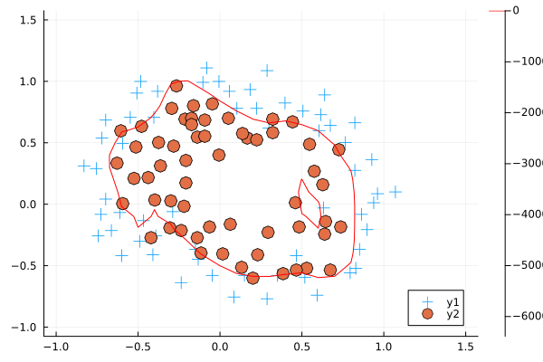

```julia
plotData(A,y)
u = -1:0.1:1.5
    v = -1:0.1:1.5
contour!(u,v,mf,levels=[0],color =:red)
```